# Dimensionality Reduction_Wk14

Faith Rotich

2/4/2022

# Wk 14 IP DIMESIONALITY REDUCTION

1. DEFINING THE QUESTION
2. METRICS OF SUCCESS
3. EXPERIMENTAL DESIGN
4. IMPLEMENTING THE SOLUTION
5. CHALLENING THE SOLUTION
6. CONCLUSION AND RECOMMENDATION
7. DEFING THE QUESTION
1. Problem Statement

You are a Data analyst at Carrefour Kenya and are currently undertaking a project that will inform the marketing department on the most relevant marketing strategies that will result in the highest no. of sales (total price including tax). Your project has been divided into four parts where you’ll explore a recent marketing dataset by performing various unsupervised learning techniques and later providing recommendations based on your insights.

Part 1: Dimensionality Reduction

This section of the project entails reducing your dataset to a low dimensional dataset using the t-SNE algorithm or PCA. You will be required to perform your analysis and provide insights gained from your analysis.

2. METRICS OF SUCCESS
- Successfully using PCA to implement dimensionality reduction
3. EXPERIMENTAL DESIGN

Data Source Link - http://bit.ly/CarreFourDataset Checking the Data Data Relevance Perform Data Cleaning Perform Exploratory Data Analysis

4. IMPLEMENTING THE SOLUTION
5. CHALLENGING THE SOLUTION
6. CONCLUSIONS AND RECOMMENDATIONS
7. FOLLOW UP QUESTIONS

A. Reading the data

```r
# Importing the necessary libraries

library (tidyverse)
library(data.table )
library(devtools)
```

```
## Error in get(genname, envir = envir) : object 'testthat_print' not found
```

```r
library(ggbiplot)
# Reading the data
data <- fread("http://bit.ly/CarreFourDataset")
```

Checking the data

```r
# Checking the first 5 rows
head(data)
```

```
##     Invoice ID Branch Customer type Gender           Product line Unit price
## 1: 750-67-8428      A        Member Female      Health and beauty      74.69
## 2: 226-31-3081      C        Normal Female Electronic accessories      15.28
## 3: 631-41-3108      A        Normal   Male     Home and lifestyle      46.33
## 4: 123-19-1176      A        Member   Male      Health and beauty      58.22
## 5: 373-73-7910      A        Normal   Male      Sports and travel      86.31
## 6: 699-14-3026      C        Normal   Male Electronic accessories      85.39
##    Quantity     Tax      Date  Time     Payment   cogs gross margin percentage
## 1:        7 26.1415  1/5/2019 13:08     Ewallet 522.83                4.761905
## 2:        5  3.8200  3/8/2019 10:29        Cash  76.40                4.761905
## 3:        7 16.2155  3/3/2019 13:23 Credit card 324.31                4.761905
## 4:        8 23.2880 1/27/2019 20:33     Ewallet 465.76                4.761905
## 5:        7 30.2085  2/8/2019 10:37     Ewallet 604.17                4.761905
## 6:        7 29.8865 3/25/2019 18:30     Ewallet 597.73                4.761905
##    gross income Rating    Total
## 1:      26.1415    9.1 548.9715
## 2:       3.8200    9.6  80.2200
## 3:      16.2155    7.4 340.5255
## 4:      23.2880    8.4 489.0480
## 5:      30.2085    5.3 634.3785
## 6:      29.8865    4.1 627.6165
```

```r
# Checking the last 5 rows
tail(data)
```

```
##     Invoice ID Branch Customer type Gender           Product line Unit price
## 1: 652-49-6720      C        Member Female Electronic accessories      60.95
## 2: 233-67-5758      C        Normal   Male      Health and beauty      40.35
## 3: 303-96-2227      B        Normal Female     Home and lifestyle      97.38
## 4: 727-02-1313      A        Member   Male     Food and beverages      31.84
## 5: 347-56-2442      A        Normal   Male     Home and lifestyle      65.82
## 6: 849-09-3807      A        Member Female    Fashion accessories      88.34
##    Quantity     Tax      Date  Time Payment   cogs gross margin percentage
## 1:        1  3.0475 2/18/2019 11:40 Ewallet  60.95                4.761905
## 2:        1  2.0175 1/29/2019 13:46 Ewallet  40.35                4.761905
## 3:       10 48.6900  3/2/2019 17:16 Ewallet 973.80                4.761905
## 4:        1  1.5920  2/9/2019 13:22    Cash  31.84                4.761905
## 5:        1  3.2910 2/22/2019 15:33    Cash  65.82                4.761905
## 6:        7 30.9190 2/18/2019 13:28    Cash 618.38                4.761905
##    gross income Rating     Total
## 1:       3.0475    5.9   63.9975
## 2:       2.0175    6.2   42.3675
## 3:      48.6900    4.4 1022.4900
## 4:       1.5920    7.7   33.4320
## 5:       3.2910    4.1   69.1110
## 6:      30.9190    6.6  649.2990
```

```r
# Checking the size of the data
dim(data)
```

```
## [1] 1000   16
```

This dataset has 1000 rows and 16 columns

```r
# Statistical Summary
summary(data)
```

```
##   Invoice ID           Branch          Customer type         Gender
##  Length:1000        Length:1000        Length:1000        Length:1000
##  Class :character   Class :character   Class :character   Class :character
##  Mode  :character   Mode  :character   Mode  :character   Mode  :character
##
##
##
##  Product line         Unit price       Quantity          Tax
##  Length:1000        Min.   :10.08   Min.   : 1.00   Min.   : 0.5085
##  Class :character   1st Qu.:32.88   1st Qu.: 3.00   1st Qu.: 5.9249
##  Mode  :character   Median :55.23   Median : 5.00   Median :12.0880
##                     Mean   :55.67   Mean   : 5.51   Mean   :15.3794
##                     3rd Qu.:77.94   3rd Qu.: 8.00   3rd Qu.:22.4453
##                     Max.   :99.96   Max.   :10.00   Max.   :49.6500
##      Date               Time             Payment               cogs
##  Length:1000        Length:1000        Length:1000        Min.   : 10.17
##  Class :character   Class :character   Class :character   1st Qu.:118.50
##  Mode  :character   Mode  :character   Mode  :character   Median :241.76
##                                                           Mean   :307.59
##                                                           3rd Qu.:448.90
##                                                           Max.   :993.00
##  gross margin percentage  gross income         Rating           Total
##  Min.   :4.762           Min.   : 0.5085   Min.   : 4.000   Min.   :  10.68
##  1st Qu.:4.762           1st Qu.: 5.9249   1st Qu.: 5.500   1st Qu.: 124.42
##  Median :4.762           Median :12.0880   Median : 7.000   Median : 253.85
##  Mean   :4.762           Mean   :15.3794   Mean   : 6.973   Mean   : 322.97
##  3rd Qu.:4.762           3rd Qu.:22.4453   3rd Qu.: 8.500   3rd Qu.: 471.35
##  Max.   :4.762           Max.   :49.6500   Max.   :10.000   Max.   :1042.65
```

```r
# Checking the data types in the columns

sapply(data, class)
```

```
##              Invoice ID                  Branch           Customer type
##             "character"             "character"             "character"
##                  Gender            Product line              Unit price
##             "character"             "character"               "numeric"
##                Quantity                     Tax                    Date
##               "integer"               "numeric"             "character"
##                    Time                 Payment                    cogs
##             "character"             "character"               "numeric"
## gross margin percentage            gross income                  Rating
##               "numeric"               "numeric"               "numeric"
##                   Total
##               "numeric"
```

B. Data Cleaning

```r
# Checking for missing values

colSums(is.na(data))
```

```
##              Invoice ID                  Branch           Customer type
##                       0                       0                       0
##                  Gender            Product line              Unit price
##                       0                       0                       0
##                Quantity                     Tax                    Date
##                       0                       0                       0
##                    Time                 Payment                    cogs
##                       0                       0                       0
## gross margin percentage            gross income                  Rating
##                       0                       0                       0
##                   Total
##                       0
```

There are no missing values in the data

```r
# checking for duplicates
duplicated_rows <- data[duplicated(data),]
duplicated_rows # there are no duplicates in the data
```

```
## Empty data.table (0 rows and 16 cols): Invoice ID,Branch,Customer type,Gender,Product line,Unit price...
```

```r
# Checking for Unique values
unique_items <- data[!duplicated(data), ]
unique_items
```

```
##        Invoice ID Branch Customer type Gender           Product line Unit price
##    1: 750-67-8428      A        Member Female      Health and beauty      74.69
##    2: 226-31-3081      C        Normal Female Electronic accessories      15.28
##    3: 631-41-3108      A        Normal   Male     Home and lifestyle      46.33
##    4: 123-19-1176      A        Member   Male      Health and beauty      58.22
##    5: 373-73-7910      A        Normal   Male      Sports and travel      86.31
##   ---
##  996: 233-67-5758      C        Normal   Male      Health and beauty      40.35
##  997: 303-96-2227      B        Normal Female     Home and lifestyle      97.38
##  998: 727-02-1313      A        Member   Male     Food and beverages      31.84
##  999: 347-56-2442      A        Normal   Male     Home and lifestyle      65.82
## 1000: 849-09-3807      A        Member Female    Fashion accessories      88.34
##       Quantity     Tax      Date  Time     Payment   cogs
##    1:        7 26.1415  1/5/2019 13:08     Ewallet 522.83
##    2:        5  3.8200  3/8/2019 10:29        Cash  76.40
```

[output cut: 21 more lines]

```r
# Selecting the numerical columns for PCA

df <- data %>% select_if(is.numeric)
colnames(df)
```

```
## [1] "Unit price"              "Quantity"
## [3] "Tax"                     "cogs"
## [5] "gross margin percentage" "gross income"
## [7] "Rating"                  "Total"
```

The numerical columns we have are Unit price, Quantity, Tax, cogs, gross margin percentage, gross income, Rating and Total

```r
head(df)
```

```
##    Unit price Quantity     Tax   cogs gross margin percentage gross income
## 1:      74.69        7 26.1415 522.83                4.761905      26.1415
## 2:      15.28        5  3.8200  76.40                4.761905       3.8200
## 3:      46.33        7 16.2155 324.31                4.761905      16.2155
## 4:      58.22        8 23.2880 465.76                4.761905      23.2880
## 5:      86.31        7 30.2085 604.17                4.761905      30.2085
## 6:      85.39        7 29.8865 597.73                4.761905      29.8865
##    Rating    Total
## 1:    9.1 548.9715
## 2:    9.6  80.2200
## 3:    7.4 340.5255
## 4:    8.4 489.0480
## 5:    5.3 634.3785
## 6:    4.1 627.6165
```

```r
# selecting needed columns

df2 <- subset(df, select = c("Unit price", "Quantity", "Tax", "cogs", "gross income", "Rating", "Total"))
colnames(df2)
```

```
## [1] "Unit price"   "Quantity"     "Tax"          "cogs"         "gross income"
## [6] "Rating"       "Total"
```

C. DIMENSIONALITY REDUCTION WITH PCA

```r
# We then pass df to the prcomp()
# We also set two arguments, center and scale,
# to be TRUE then preview our object with summary
# ---
#
df2.pca <- prcomp(df, center = FALSE, scale. = TRUE)
summary(df2.pca)
```

```
## Importance of components:
##                           PC1     PC2     PC3     PC4    PC5       PC6
## Standard deviation     2.6793 0.75856 0.44411 0.18912 0.1130 1.286e-16
## Proportion of Variance 0.8973 0.07193 0.02465 0.00447 0.0016 0.000e+00
## Cumulative Proportion  0.8973 0.96928 0.99393 0.99840 1.0000 1.000e+00
##                              PC7       PC8
## Standard deviation     7.879e-17 3.312e-17
## Proportion of Variance 0.000e+00 0.000e+00
## Cumulative Proportion  1.000e+00 1.000e+00
```

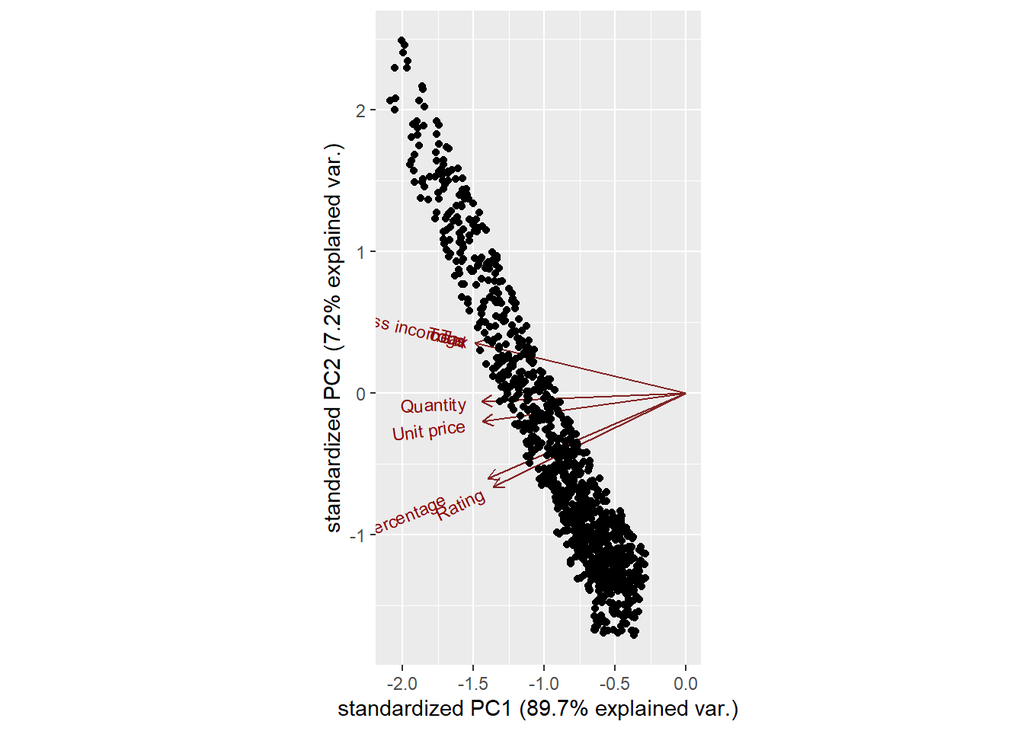

```r
library(ggbiplot)
ggbiplot(df2.pca)
```

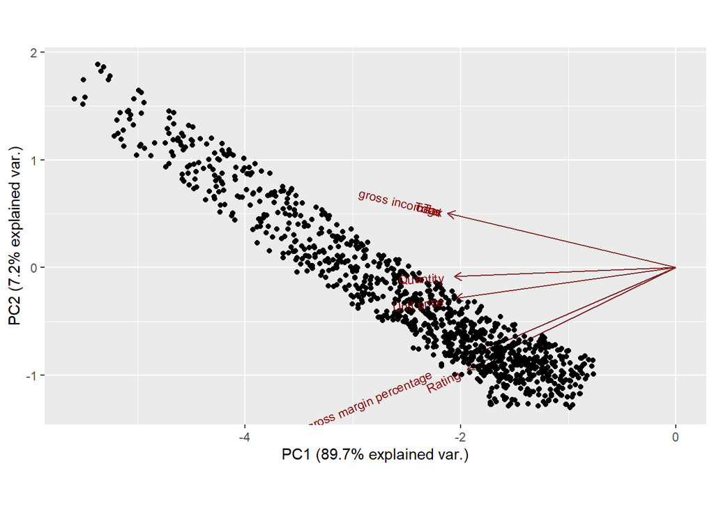

```r
# Adding more detail to the plot, we provide arguments rownames as labels
#
ggbiplot(df2.pca, labels=rownames(df2.pca), obs.scale = 1, var.scale = 1)
```